# Projet tutoret Francois

francois bettega

15/01/2020

# Problème Rencontré avec les données

### Choix de prétraitement

- Au totale 8591 mesure on comme valeurs zero nous avons choisis de les retirer du data-set.
- Parmis les mesures restante la variable Monday (jour de la mesures) est mal encodé pour un patient elle prend normalement 1 ou 2. Mais prend ici comme valeurs -364 et -363 nous avons choisis de la reéencoder en 1 et 2

### Problème non résolue

- Mesures effectuers a des moments différents (minutes différentes pour les patients) proposer une structure de données permetttant de conserver cette information en rendant les courbes comparables. :
  - Hypothèse assez forte : Nous avons choisis de considérer que la pression artérielle ne varié pas être deux mesures. exemple avec deux patients ci-dessous

| Exemple de données pour deux patients avec les NA | Exemple de données pour deux patients avec les NA 11.9 | Exemple de données pour deux patients avec les NA 12.15 | Exemple de données pour deux patients avec les NA 12.7166666666667 | Exemple de données pour deux patients avec les NA 13.65 | Exemple de données pour deux patients avec les NA 14.15 | Exemple de données pour deux patients avec les NA 14.4 | Exemple de données pour deux patients avec les NA 14.65 | Exemple de données pour deux patients avec les NA 14.9 | Exemple de données pour deux patients avec les NA 15.15 | Exemple de données pour deux patients avec les NA 15.4 |
| --- | --- | --- | --- | --- | --- | --- | --- | --- | --- | --- |
| patient 1 | 141 | 151 | 140 | 145 | 146 | 140 | 129 | 119 | 129 | 116 |
| patient 2 |  |  |  |  |  |  |  |  |  | 143 |

| Exemple de données pour deux patients avec les complété | Exemple de données pour deux patients avec les complété 11.9 | Exemple de données pour deux patients avec les complété 12.15 | Exemple de données pour deux patients avec les complété 12.7166666666667 | Exemple de données pour deux patients avec les complété 13.65 | Exemple de données pour deux patients avec les complété 14.15 | Exemple de données pour deux patients avec les complété 14.4 | Exemple de données pour deux patients avec les complété 14.65 | Exemple de données pour deux patients avec les complété 14.9 | Exemple de données pour deux patients avec les complété 15.15 | Exemple de données pour deux patients avec les complété 15.4 |
| --- | --- | --- | --- | --- | --- | --- | --- | --- | --- | --- |
| patient 1 | 141 | 151 | 140 | 145 | 146 | 140 | 129 | 119 | 129 | 116 |
| patient 2 | 143 | 143 | 143 | 143 | 143 | 143 | 143 | 143 | 143 | 143 |

Par exmple entre deux patients : - Un ayant commencer à 12h et finis à 12h le lendemain - Le second ayant commencer à 8 h et finis a 8 h le lendemain

Avec mon traitement actuelle de données les valeurs des mesures après 12h sont bien aligné pour les deux patients

Mais les mesures avant 12 h par exemple 10 h ne le sont pas car effectué sur des jours différents.

Je cherche encore une bonne solution.

Pour le moment je travail avec une mesure par heure par patients et en cas de plusieurs mesures j’utilise la moyenne des mesures.

# Présentations

Données difficilement lisible, représentations d’une tendance avec la courbe moyenne.

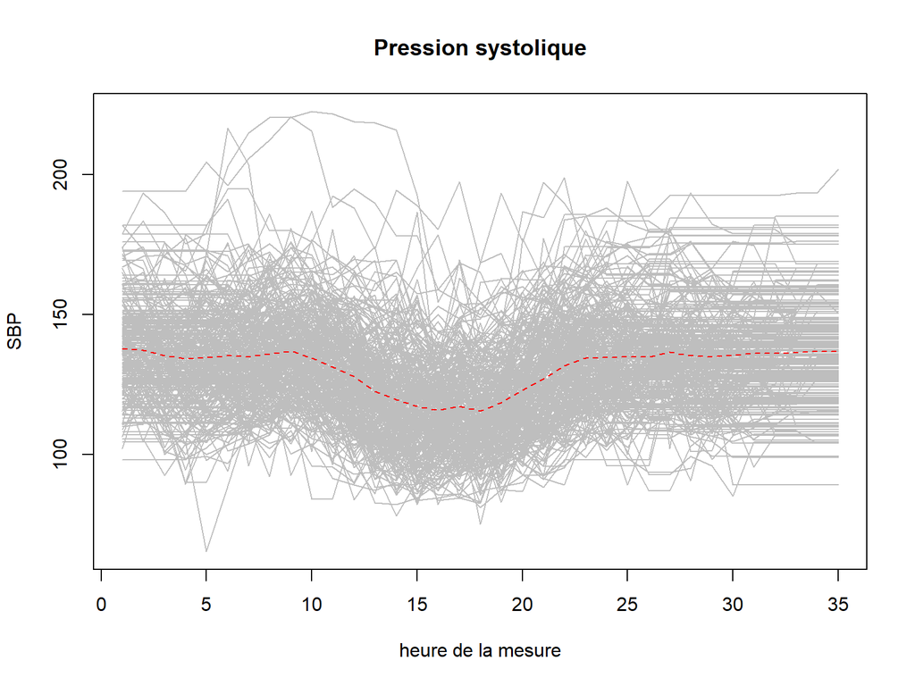

Nos données coloré en fonction du score AHI  
- Noire < 15 - Rouge [15,30] - Vert > 30

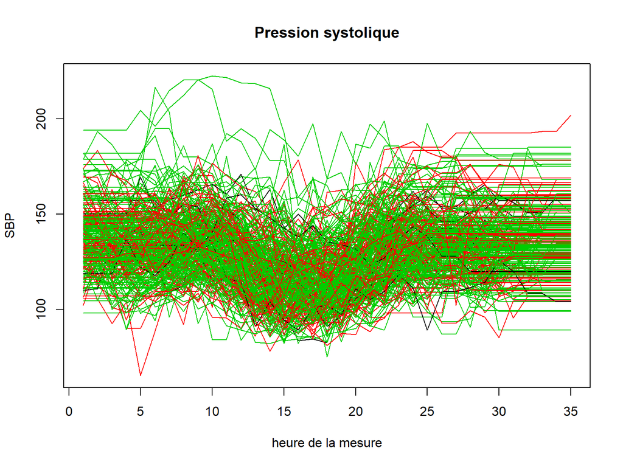

# Premiere approche

Utilisation de la dérivé de la courbe de pression pour évaluer ça variabilité.

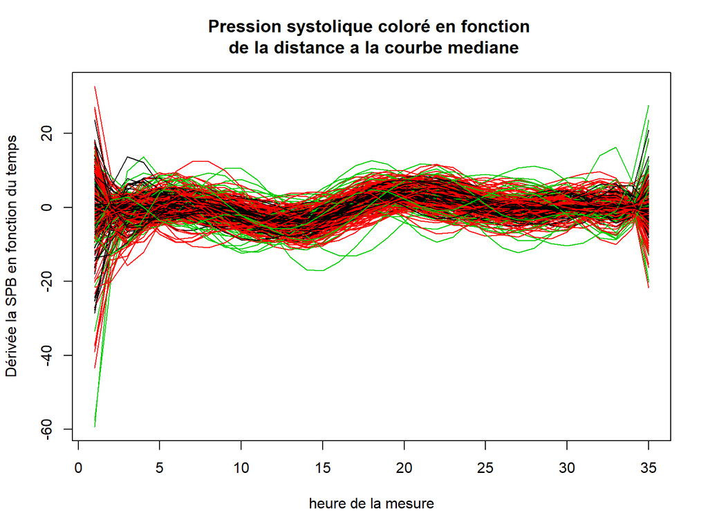

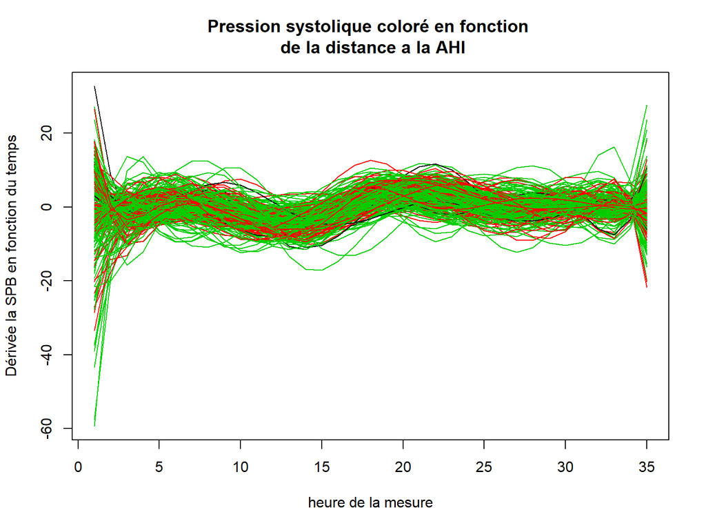

- Premier difficulté Répartission très inégale de nos patients selon les groupes : très grande majorité des patients avec une AHI supérieur a 30.
- Début et fin de graph problématique mais ce problème et résolue si on utilise les mesures prise a la minute pret.

Evaluation de la valeurs absolue de la dérivée

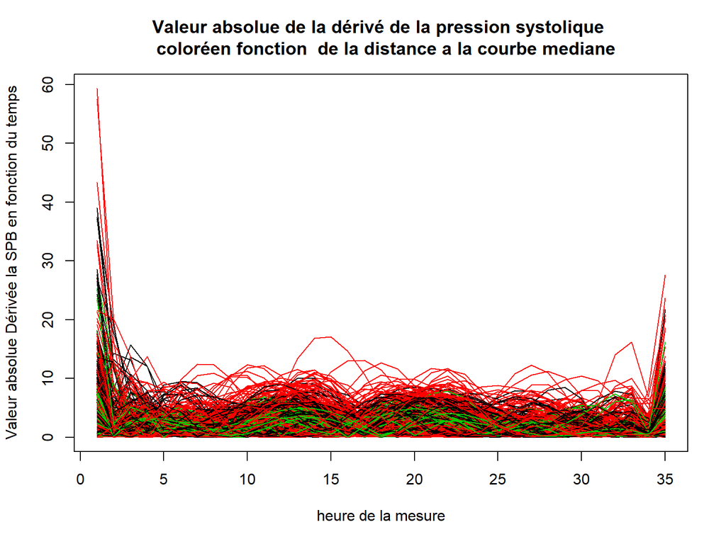

Abandon car n’apporte rien par rapport a la dérivé seul.

### Avenir potentiel de cette approche

- Discussion de l’utilisation de la valeur de la dérivé ou du nombres de fois ou elle s’annule.
- Utilisation des fonctions de mesure de position et de dispertion pour forme fonctionnel **manque de temps**

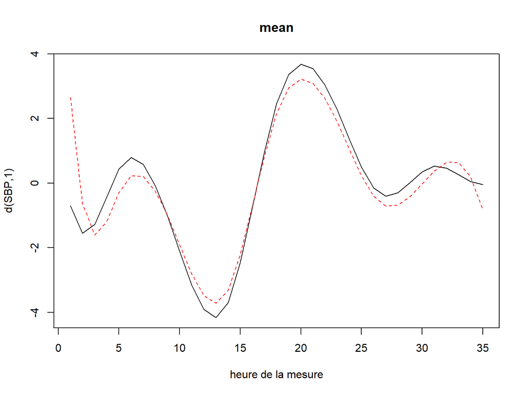

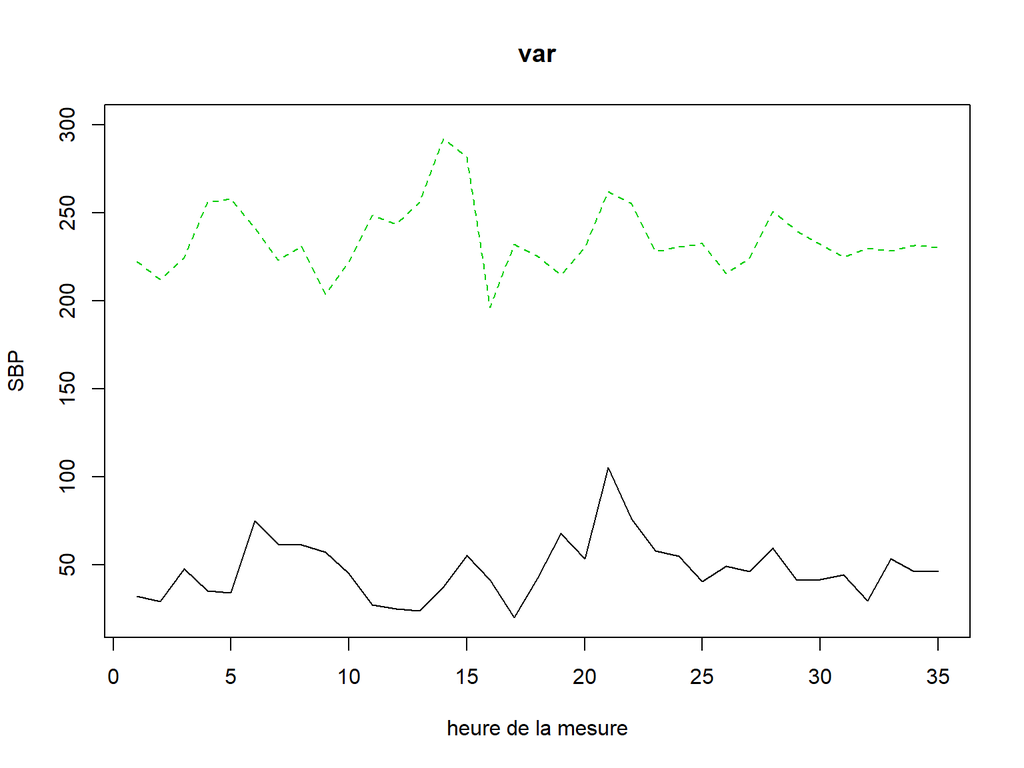

# Seconde approche

- On centre les pression systolique pour les rendres comparable d’un patients a l’autres
- Variance par patient
- Prediction avec un SVM score sur cross-validation a 5 folds.

```
## # A tibble: 6 x 3
##   UNID                                 var_SBC VAR45
##   <fct>                                  <dbl> <fct>
## 1 00abb1bc-7621-4e68-8fe9-cb63838ae9ca  0.0566 3
## 2 00cddb53-7b81-43db-98bb-1462e7843957  0.0285 2
## 3 010037c3-c29f-4d72-8d55-765a491164bd  0.0609 3
## 4 011f89f7-90b8-407b-9050-175194e9f9ea  0.0399 3
## 5 01e13b8b-4fa9-428c-ac47-f55006524c0b  0.0529 3
## 6 020634da-7921-424a-b2c2-827ddb24bebb  0.0271 3
```

```
## [1] 0.6820631
```

# outils potentiellement utile

### transormation

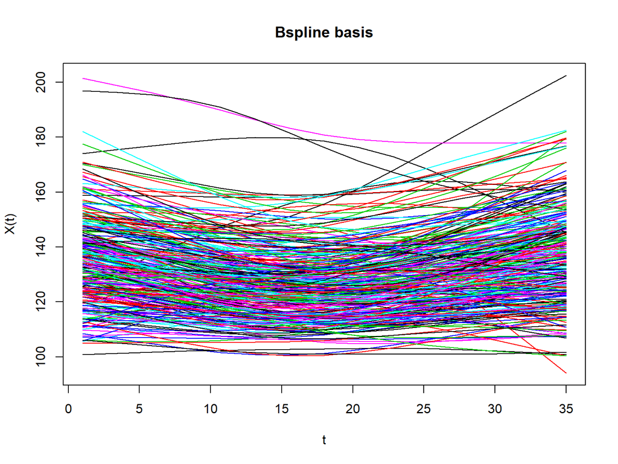

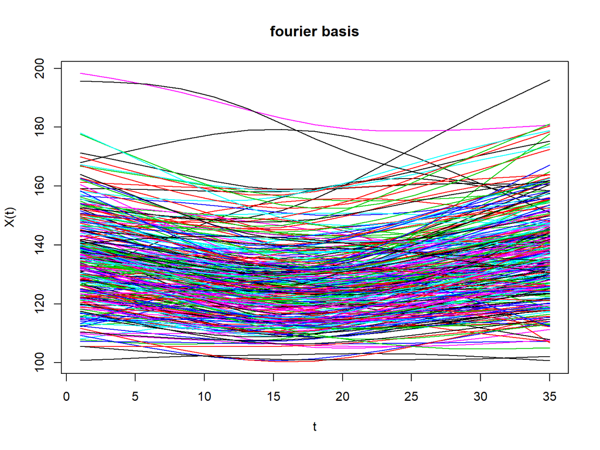

### PCA et clusturing

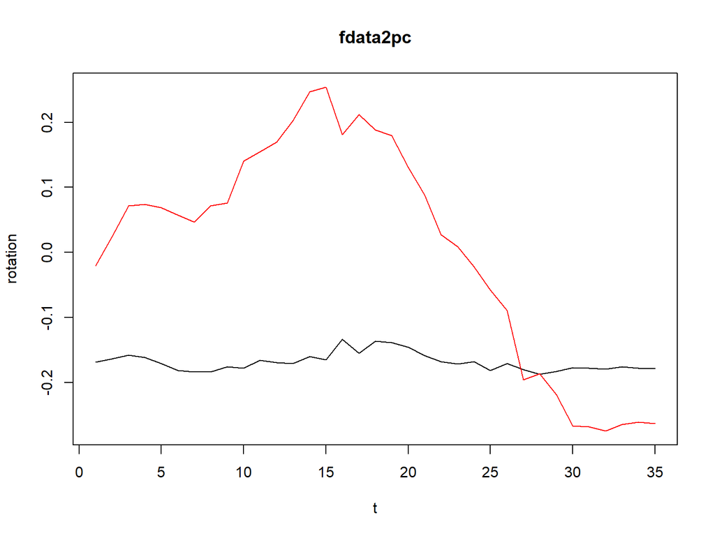